# Defining promoters

Martin Iungman

2022-08-12

Este informe incluye el analisis de los true TSS de FANTOM5 y los promotores de la base de datos EPD.

# FANTOM5 True TSS

Esta sección toma el script de promoter_id.R, para identificar los “true TSS clusters” propuestos por FANTOM5.  
Luego toma el script distances.R para estimar las distancias entre los clusters dentro de cada gen

### Pre processing

El archivo BED de FANTOM esta bajo el nombre “TSS_human.bed”

```
## Contiene 1048124 Ranges totales.
```

```
## De los cuales  217572 superan el umbral de score 0.228 propuesto por FANTOM5 para asignar los True TSS.
```

```
## Estos ultimos están asociados a 48258 elementtos génicos (genes o transcriptos)
```

```
## # A tibble: 6 × 2
##      id name
##   <int> <chr>
## 1     1 PYROXD2
## 2     2 HPS1
## 3     3 HPSE2
## 4     4 CNNM1
## 5     5 GOT1
## 6     6 ENST00000416191
```

```
## [1] "En algunos casos está asociado a gene symbol y otros a ID de transcripto. Lo queremos unificar"
```

Descargo los IDs de ENSEMBL (en archivo ensembl_genes_grch37.txt descargado por Biomart) para unificar nomenclatura.

```
## Contiene 196354 transcriptos y  55773 gene symbols distintos
```

```
## # A tibble: 6 × 4
##   gene_id         tx_id           gene_symbol  chr
##   <chr>           <chr>           <chr>        <fct>
## 1 ENSG00000271782 ENST00000607815 RP5-850O15.4 1
## 2 ENSG00000232753 ENST00000424955 RP11-347K2.1 1
## 3 ENSG00000225767 ENST00000424664 RP5-850O15.3 1
## 4 ENSG00000202140 ENST00000365270 Y_RNA        1
## 5 ENSG00000207194 ENST00000384465 RNU6-1026P   1
## 6 ENSG00000252825 ENST00000517016 RNU6-1253P   1
```

Que true TSS estan asociados a un gene symbol? Y cuales a un transcript ID?

```
## De lo los 48258 elementos genicos asociados a True TSS, 17322 asociados a gene_id y 4521 asociados a transcript ID
```

```
## Tenemos ahora 160703 cluster_id distintos, con 21795 gene_ids y
## 20317 gene_symbol. Hay una diferencia entre gene_id y gene_symbol porque hay casos en los que un ID esta asignado a varios Symbol y viceversa.
```

### Numero de promotores por gen

```
##  gene_symbol            n_prom
##  Length:20317       Min.   :   1.000
##  Class :character   1st Qu.:   3.000
##  Mode  :character   Median :   6.000
##                     Mean   :   8.574
##                     3rd Qu.:  10.000
##                     Max.   :8866.000
```

```
## [1] "se ve claramente un outlier al menos... 8800 son muchos promotores. Veamos a quien corresponden"
```

```
## # A tibble: 6 × 2
##   gene_symbol n_prom
##   <chr>        <int>
## 1 Y_RNA         8866
## 2 snoU13        2325
## 3 TTN            116
## 4 DST             90
## 5 FLNA            79
## 6 CPLX2           78
```

```
## [1] "Ademas de Y_RNA, snoU13 tambien tiene enorme cantidad de promotores. Los voy a excluir"
```

```
## Finalmente tenemos 160687 cluster_id distintos, con 20524 gene_ids y
## 20315 gene_symbol. Se acercaron los valores de gene_symbol y gene_id.
```

```
##  gene_symbol            n_prom
##  Length:20315       Min.   :  1.000
##  Class :character   1st Qu.:  3.000
##  Mode  :character   Median :  6.000
##                     Mean   :  8.024
##                     3rd Qu.: 10.000
##                     Max.   :116.000
```

```
##    gene_id              n_prom
##  Length:20524       Min.   :  1.000
##  Class :character   1st Qu.:  3.000
##  Mode  :character   Median :  6.000
##                     Mean   :  7.942
##                     3rd Qu.: 10.000
##                     Max.   :116.000
```

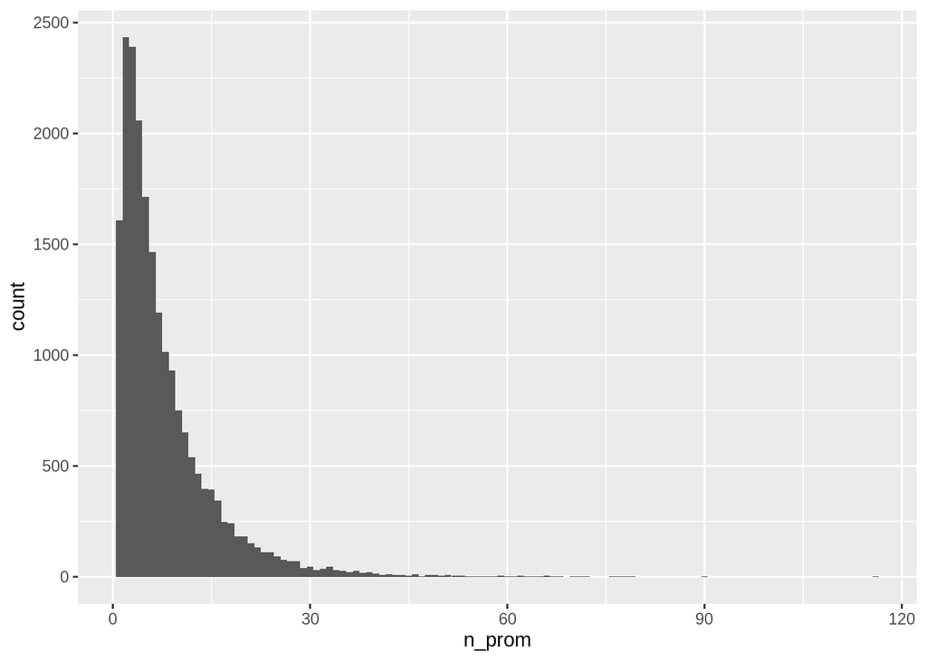

### Cluster width

Calculo el ancho de los clusters y veo su distribucion

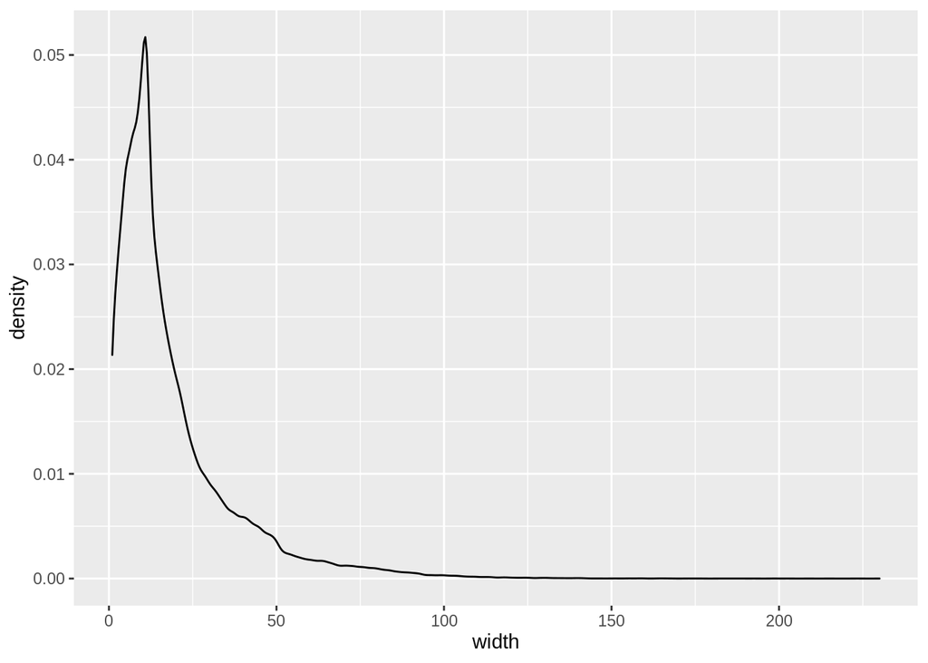

### Calculo la distancia al promotor mas cercano dentro del mismo gen

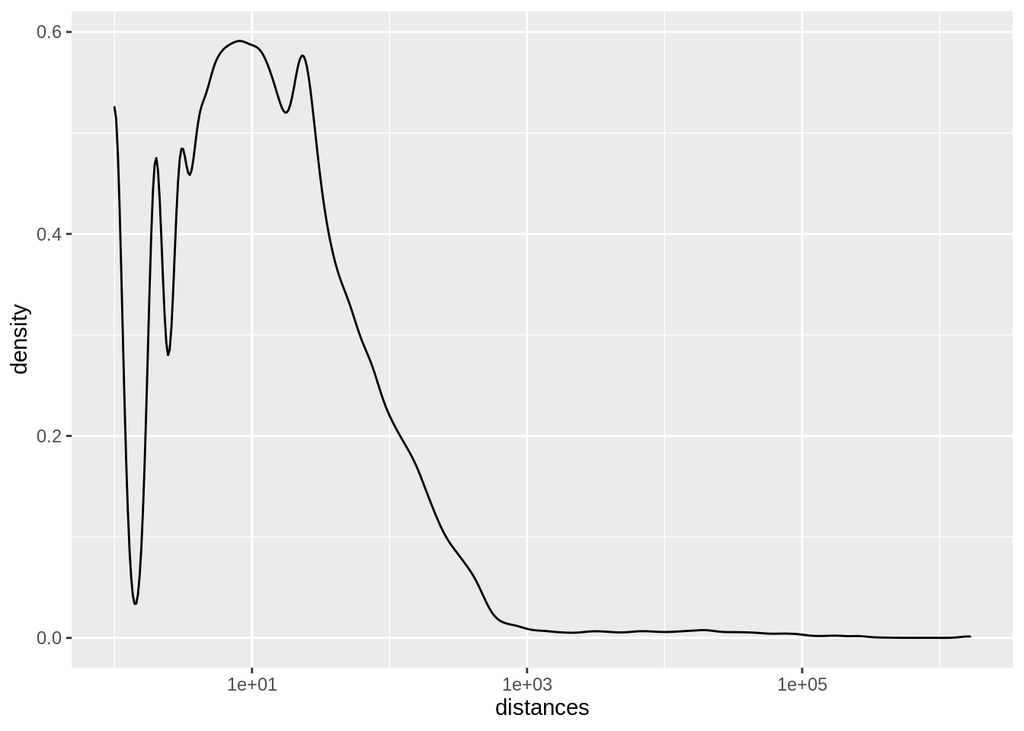

La cercanía entre los TSS clusters implica que no haya independencia en el efecto de los elementos asociados a cada promotor. Necesitamos una forma de unificar TSS asociados.

# EPD database

## <epd.vital-it.ch/EPDnew_select.php>

Este analisis esta hecho en base al script EP_promoter_analysis.R El archivo con la totalidad de promotores está en All_promoters.bed

Hago un histograma de numero de promotores por gen

```
## De los 16455 genes, hay  8022 genes con mas de un promotor
```

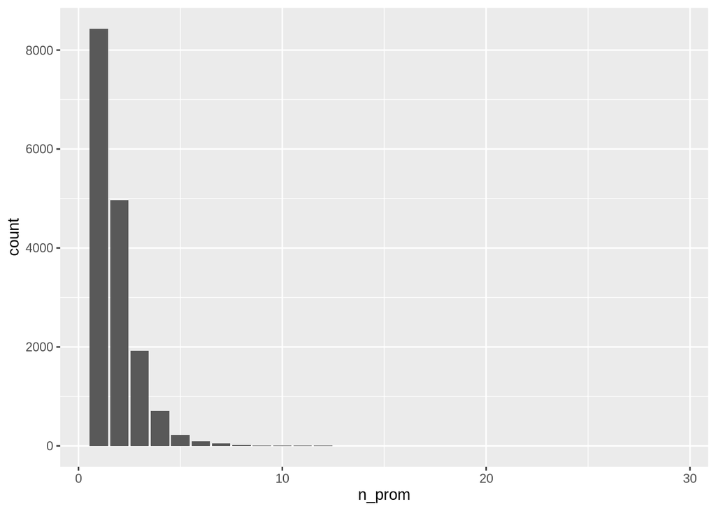

```
##      gene               n_prom
##  Length:16455       Min.   : 1.000
##  Class :character   1st Qu.: 1.000
##  Mode  :character   Median : 1.000
##                     Mean   : 1.799
##                     3rd Qu.: 2.000
##                     Max.   :29.000
```

No veo outliers. Good

Calculo distancias intragenicas entre promotores

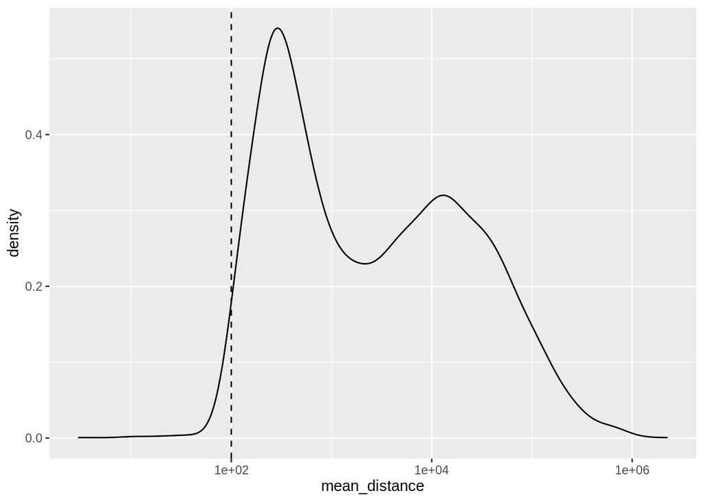

Si bien tiene grandes limitaciones esta base de datos, la puedo usar como exploratoria.